# Prediction Assignment Writeup

FD

30 Mai 2016

## Summary

This presentation is about predicting the type of exercise for 20 subjects based on sensor data from weight lifting experiments. For the background and reference please see (Velloso E. et al. 2013). Two models are fitted: Random forest and generalized boosted regression model. Random forest give the best accuracy on the test set and is used for prediction. This work is done in the context of the Coursera Data Science Specialization course.

## Data

The training and test data is downloaded from the course website. The training data contains a classification (*classe*), which indicates the type of exercise done. It is indicated by a character between A and E. The test data contain some columns with missing values, which will be skipped in the analysis (model is used for the prediction in the given test set only).

The data contain columns, which are not useful for prediction (number of data point, subject name, …). These data are located in the first 7 columns and skipped. *This also includes the timepoint of the measurement, neglecting any time-dependent effects in the further analysis.*

After data cleanup, there are no zero variance variables in the training set. The data consists, after the clean up, of 52 variables all of numerical type.

```r
library(caret)
if(!file.exists("pml-training.csv")){
  download.file("https://d396qusza40orc.cloudfront.net/predmachlearn/pml-training.csv", "pml-training.csv")
}
if(!file.exists("pml-testing.csv")){
  download.file("https://d396qusza40orc.cloudfront.net/predmachlearn/pml-testing.csv", "pml-testing.csv")
}

training<-read.csv("pml-training.csv")
predictionData<-read.csv("pml-testing.csv")

noTestData<-colSums(!is.na(predictionData))==nrow(predictionData)
smallTraining<-training[,noTestData]
smallPredictionData<-predictionData[,noTestData]

smallTraining<-smallTraining[,c(-1, -2, -3, -4, -5, -6, -7)]
smallPredictionData<-smallPredictionData[,c(-1, -2, -3, -4, -5, -6, -7)]

zero<-nearZeroVar(smallTraining)
print(zero)
```

```
## integer(0)
```

To test the out of sample error, the training set is split in train and test data.

```r
set.seed(1234)
inTrain=createDataPartition(smallTraining$classe, p=0.6, list=F)
```

## Model training

Two models (random forest and gbm) are trained, both should be giving good accuracy for the given problem. For gbm, 150 boosting iterations are used. 5-fold cross validation is used on both models.

Both models give the most importance to the variable *roll_belt*, the remaining order is similar but not equal. Random forest performs slightly better than gbm and leads to an out-of-sample accuracy of 0.9912 compared with 0.9583 for gbm.

```r
library(reshape2)

trControl<-trainControl(method="cv", number=5, allowParallel=T)
m1<-train(classe~., method="rf", data=smallTraining[inTrain,], trControl=trControl)
m2<-train(classe~., method="gbm", data=smallTraining[inTrain,], trControl=trControl)
c1=confusionMatrix(predict(m1, newdata=smallTraining[-inTrain,]), smallTraining[-inTrain,]$classe)
c2=confusionMatrix(predict(m2, newdata=smallTraining[-inTrain,]), smallTraining[-inTrain,]$classe)

print(c1)
```

```
## Confusion Matrix and Statistics
##
##           Reference
## Prediction    A    B    C    D    E
##          A 2232   13    0    0    0
##          B    0 1503   11    0    0
##          C    0    2 1351   29    3
##          D    0    0    6 1255    3
##          E    0    0    0    2 1436
##
## Overall Statistics
##
##                Accuracy : 0.9912
##                  95% CI : (0.9889, 0.9932)
##     No Information Rate : 0.2845
##     P-Value [Acc > NIR] : < 2.2e-16
##
##                   Kappa : 0.9889
##  Mcnemar's Test P-Value : NA
##
## Statistics by Class:
##
##                      Class: A Class: B Class: C Class: D Class: E
## Sensitivity            1.0000   0.9901   0.9876   0.9759   0.9958
## Specificity            0.9977   0.9983   0.9948   0.9986   0.9997
## Pos Pred Value         0.9942   0.9927   0.9755   0.9929   0.9986
## Neg Pred Value         1.0000   0.9976   0.9974   0.9953   0.9991
## Prevalence             0.2845   0.1935   0.1744   0.1639   0.1838
## Detection Rate         0.2845   0.1916   0.1722   0.1600   0.1830
## Detection Prevalence   0.2861   0.1930   0.1765   0.1611   0.1833
## Balanced Accuracy      0.9988   0.9942   0.9912   0.9873   0.9978
```

```r
print(c2)
```

```
## Confusion Matrix and Statistics
##
##           Reference
## Prediction    A    B    C    D    E
##          A 2201   50    0    0    1
##          B   16 1421   50    3   25
##          C    8   45 1289   43   19
##          D    5    0   26 1230   19
##          E    2    2    3   10 1378
##
## Overall Statistics
##
##                Accuracy : 0.9583
##                  95% CI : (0.9537, 0.9626)
##     No Information Rate : 0.2845
##     P-Value [Acc > NIR] : < 2.2e-16
##
##                   Kappa : 0.9473
##  Mcnemar's Test P-Value : 1.576e-11
##
## Statistics by Class:
##
##                      Class: A Class: B Class: C Class: D Class: E
## Sensitivity            0.9861   0.9361   0.9423   0.9565   0.9556
## Specificity            0.9909   0.9851   0.9822   0.9924   0.9973
## Pos Pred Value         0.9774   0.9380   0.9181   0.9609   0.9878
## Neg Pred Value         0.9945   0.9847   0.9877   0.9915   0.9901
## Prevalence             0.2845   0.1935   0.1744   0.1639   0.1838
## Detection Rate         0.2805   0.1811   0.1643   0.1568   0.1756
## Detection Prevalence   0.2870   0.1931   0.1789   0.1631   0.1778
## Balanced Accuracy      0.9885   0.9606   0.9622   0.9744   0.9765
```

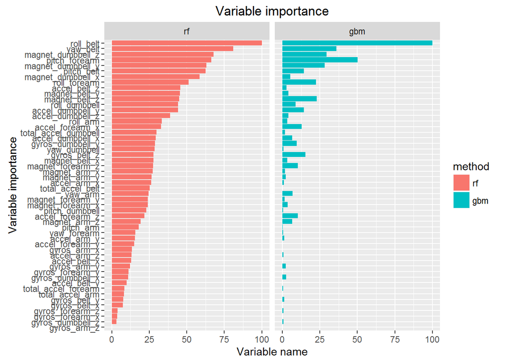

```r
v1<-varImp(m1)$importance
v2<-varImp(m2)$importance

prePlotData<-cbind(rf=v1, gbm=v2)
colnames(prePlotData)=c("rf", "gbm")
plotData<-melt(as.matrix(prePlotData), id.vars=c(1, 2))
colnames(plotData)<-c("variableName", "method", "value")
p<-ggplot(plotData,aes(x = variableName,y = value)) + geom_bar(aes(fill = method),position = "dodge", stat="identity")+coord_flip()+facet_grid(~method)+scale_x_discrete(limits=rownames(v1)[order(v1, decreasing=F)])+labs(x="Variable importance", y="Variable name", title="Variable importance")
print(p)
```

## Predicting 20 unknown cases

```r
predicted<-predict(m1, newdata=smallPredictionData)
print(predicted)
```

```
##  [1] B A B A A E D B A A B C B A E E A B B B
## Levels: A B C D E
```

## Reference

Velloso E., Bulling A., Gellersen H., Ugulino W., and Fuks H. 2013. “Qualitative Activity Recognition of Weight Lifting Exercises.” *Proceedings of 4th International Conference in Cooperation with SIGCHI (Augmented Human ’13)*.